# Exercice 1: Visualisation des données

19 juillet 2025

## Exercice 1

Vous utiliserez le fichier de données **mig** fourni sous format **.csv.**

1. Importer le fichier **mig.csv** dans RStudio.
2. Créer un graphique à bandes empilées représentant la fréquence par province et territoires (**location**) selon le type de migration (**type**). Colorier les bandes selon le type de migration, labéliser convenablement les axes et donner un titre au graphique.

```
## # A tibble: 6 × 5
##    year quarter location                  type         persons
##   <dbl>   <dbl> <chr>                     <chr>          <dbl>
## 1  1961       3 Newfoundland and Labrador in-migration    2189
## 2  1961       4 Newfoundland and Labrador in-migration    1559
## 3  1962       1 Newfoundland and Labrador in-migration    1015
## 4  1962       2 Newfoundland and Labrador in-migration    1015
## 5  1962       3 Newfoundland and Labrador in-migration    2036
## 6  1962       4 Newfoundland and Labrador in-migration    1816
```

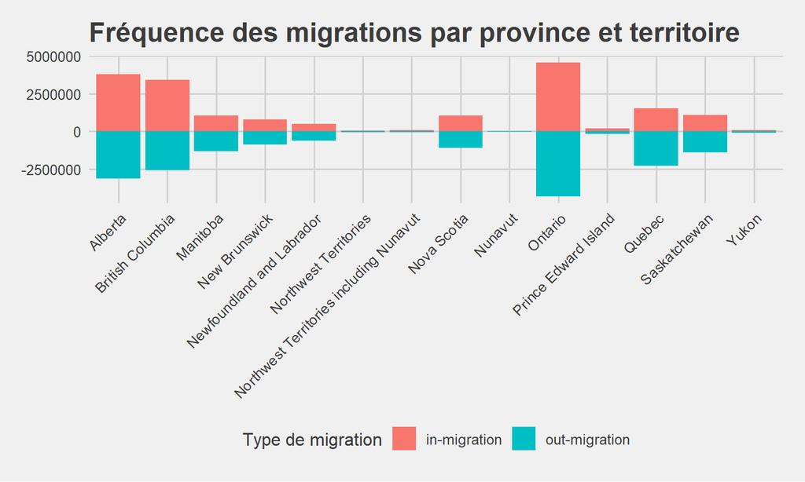

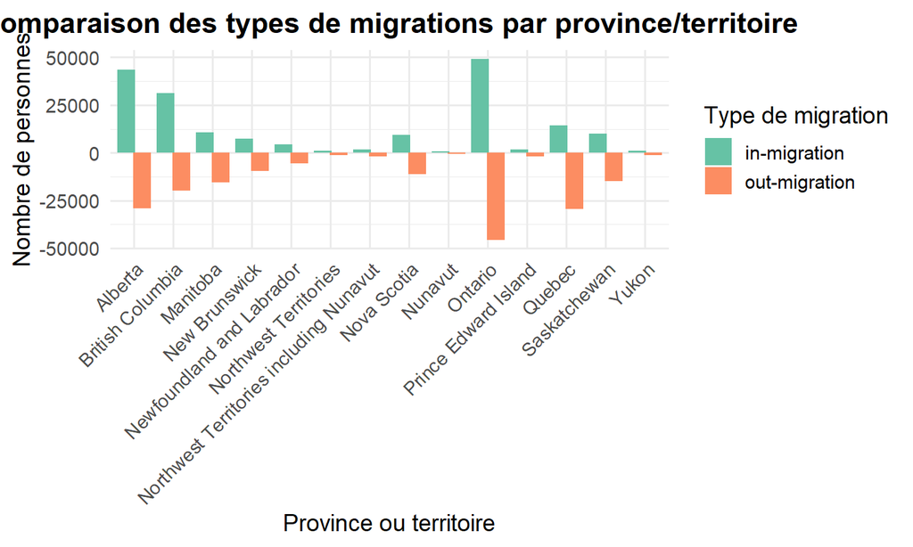

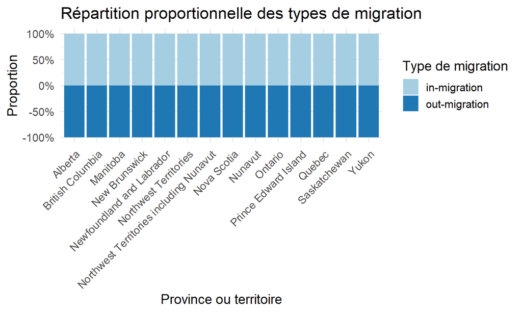

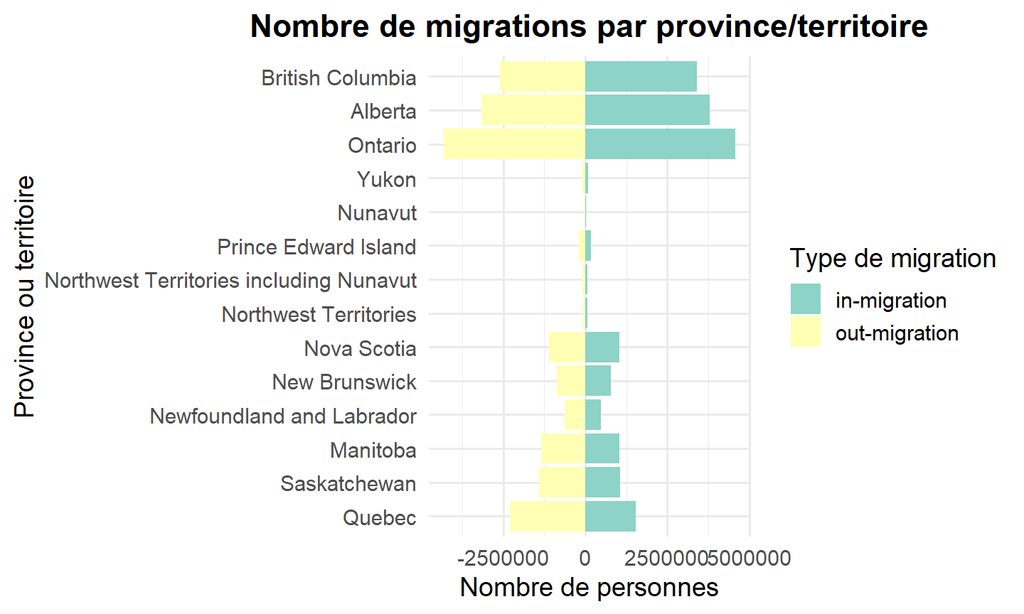

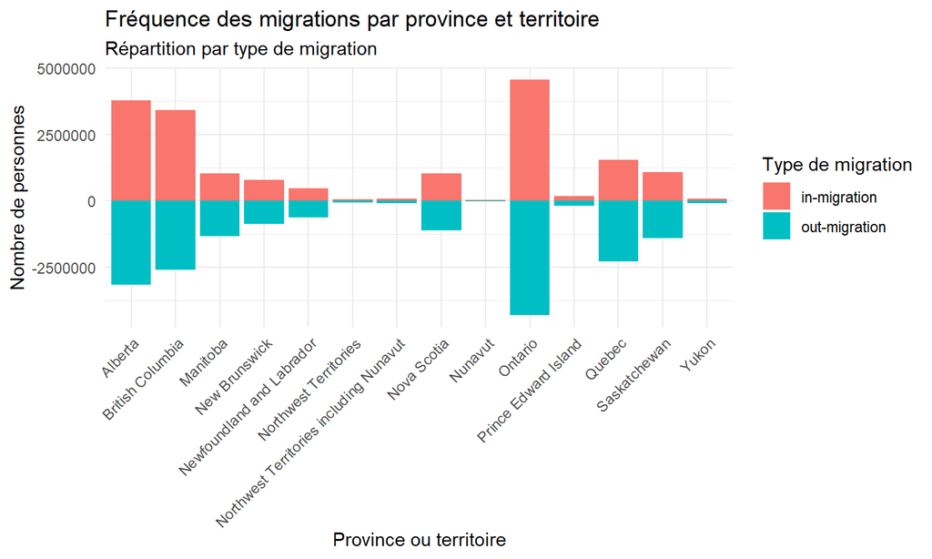

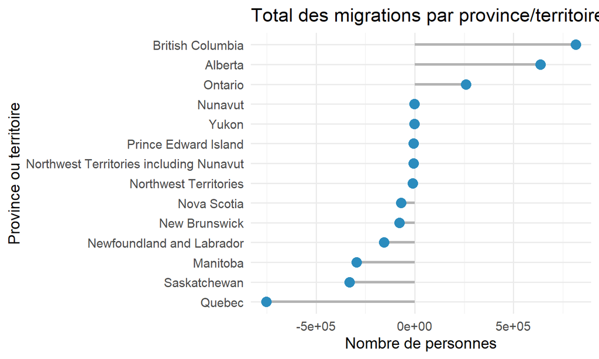

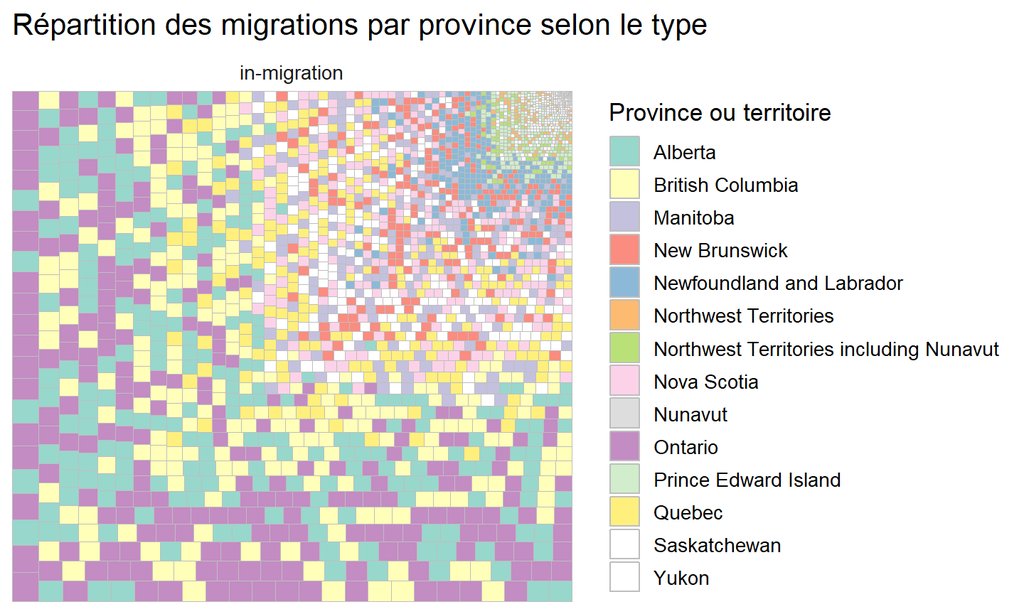

## Exercice 2

**Youtube_dataset_all_dataScience_channels.csv** est un ensemble de données qui fournit un aperçu détaillé des chaînes YouTube dédiées à la science des données et à l’analyse. Il comprend 22862 lignes, chacune représentant une vidéo unique avec différentes mesures d’engagement et détails de publication. L’ensemble de données vise à aider les chercheurs, les analystes de données et les passionnés à explorer et à analyser les tendances au sein de la communauté de la science des données sur YouTube.

https://www.kaggle.com/datasets/abhishek0032/youtube-dataset-all-data-scienceanalyst-channels

## A. Questions de visualisation

1. Proposez un moyen d’identifier visuellement les vidéos “virales” (à fort ratio likes/vues ou commentaires/vues).
2. Proposez un graphique combinant barres et lignes pour mettre en valeur à la fois la fréquence de publication et l’engagement moyen par type.

## B. Questions d’utilisation d’une Shiny app

1. Quels contrôles (`selectInput`, `sliderInput`, `checkboxGroupInput`, etc.) incluriez-vous pour permettre à l’utilisateur de choisir une ou plusieurs chaînes à analyser ?
2. Quels contrôles incluriez-vous pour permettre à l’utilisateur de sélectionner une plage de dates précise ?
3. Quels conseils donneriez-vous pour optimiser les temps de chargement lorsque l’utilisateur manipule plusieurs filtres simultanément ?
4. Proposez un agencement de la page Shiny combinant un panneau de contrôle, deux visualisations côte à côte et un tableau interactif.
5. Comment implémenteriez-vous un module Shiny pour comparer dynamiquement deux chaînes sélectionnées par l’utilisateur ?

## 6- Quel élément graphique (barres horizontales, dot plot, etc.) choisir pour faciliter la comparaison ?